# ParkrunUKFinder App

Nathalie Descusse-Brown  
29th April 2019

[figure not shown]

## What is Parkrun?

Parkrun is a series of free 5k runs held on Saturday mornings in areas of open space around the UK. They are so popular than a phenomenon appeared in the form of the ParkRun alphabet where participants try and run ParkRuns in different towns starting with each letter of the alphabet. This app is designed to make it easier for them to find a nearby ParkRun starting by the letter of their choice!

## How does the ParkrunFinder app work?

- Scrapes https://en.wikipedia.org/wiki/List_of_Parkruns_in_the_United_Kingdom website. A check was performed with the R package robotstxt to ensure scraping of this site was allowed.
- Returns the list of all parkruns.
- Interrogates associated hyperlinks (town's page in wiki) to look up associated latitude/longitude.
- Looks up latitude/longitude of user-entered postcode by looking it up in table downloaded from https://www.freemaptools.com/download-uk-postcode-lat-lng.htm.
- Calculates haversine ('as-the-crow-flies') distance between Parkrun location and user postcode.
- Returns list of Parkruns ordered by distance from the user postcode.
- User can filter further by selecting first letter of Parkrun location, in order to tick it off own Parkrun alphabet!

## What the app looks like

The left hand side gives instructions for use and has a box for free text input of postcode and dropdown menu for selection of first letter of ParkRun event town.

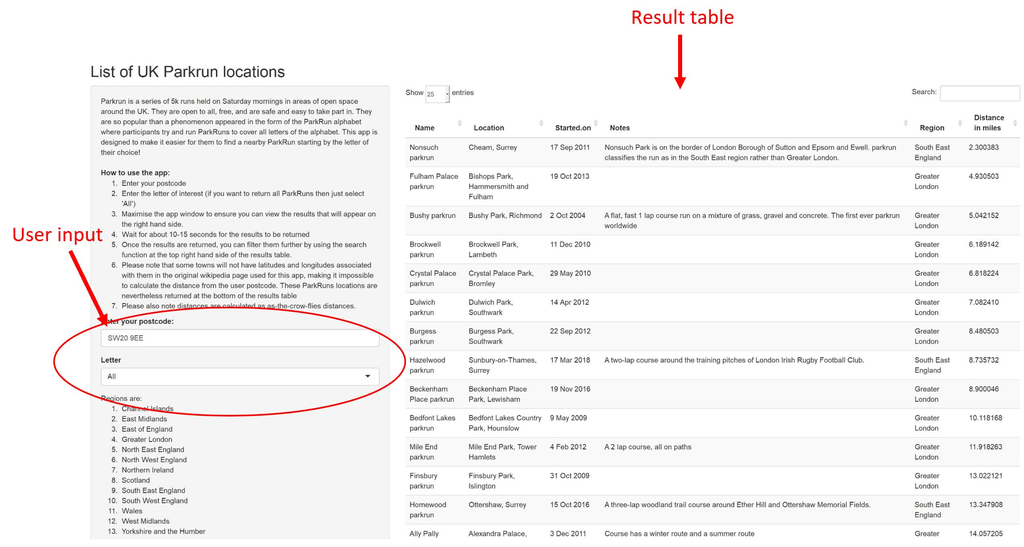

## How to use the app

### Please note that some towns will not have latitudes and longitudes associated with them in the original wikipedia page used for this app, making it impossible to calculate the distance from the user postcode. These ParkRuns locations are nevertheless returned at the bottom of the results table. Please also note distances are calculated as as-the-crow-flies distances.

## The back end of the app

```r
source('C:/Users/natha/Developing_Data_Products/ParkRunFinderPlus/findParkrunUKplusdistance.R')
results <- findParkrunUKplusdistance("SW15 3TR")
head(results[order(results[,6]),c(1,6)],5)
```

```
                     Name Distance in miles
130 Fulham Palace parkrun          1.620577
118     Brockwell parkrun          5.244188
121         Bushy parkrun          5.286177
383       Nonsuch parkrun          5.691658
127       Dulwich parkrun          6.490548
```